# Entrega Aula 9 - FDP

## Gabriel França e Felipe Buniac

### Distribuiçao Tipo Normal

2) Há outros modelos probabilísticos contínuos:

- Uniforme
- Normal
- Gamma
- t-Student
- LogNormal
- Beta
- F-Snedecor

Cada grupo de alunos deve ficar com uma distribuição e deve realizar as seguintes atividades (**num IPython Notebook à parte**, que deve ser publicado no **Github** e ter seu link divulgado para a sala até 24/9):

2.1. Gere um plot da densidade de probabilidade da distribuição e de sua cumulativa. Descubra como usando o pacote scipy.stats

2.2. Qual a forma analítica (expressão) da distribuição?

2.3. Quais parâmetros descrevem a distribuição?

2.4. Existe uma fórmula específica para calcular esperança (média) e variáncia em função dos parâmetros?

2.5. Que tipo de aplicações tem esta distribuição? Em que tipo de dados é normalmente encontrada?

2.6. Essa distribuição é útil para a inferência estatística? (Os Capítulos 7 e 8 do Magalhães darão uma idéia de se sim ou não)

```
0.0
1.0
```

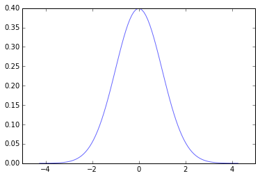

```python
%matplotlib inline

import os
import matplotlib.pyplot as plt
import pandas as pd
from scipy.stats import norm
import numpy as np

s = 0
mean, var, skew, kurt = norm.stats(s, moments='mvsk')
print(mean)
print(var)
x = np.linspace(norm.ppf(0.00001, s),norm.ppf(0.99999, s), 100)
plt.plot(x, norm.pdf(x, s),'b-', lw=1, alpha=0.6, label='norm pdf')
```

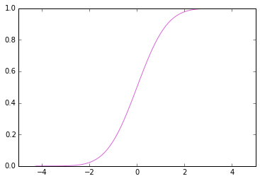

```python
x = np.linspace(norm.ppf(0.00001, s),norm.ppf(0.99999, s), 100)
plt.plot(x, norm.cdf(x, s),'m-', lw=1, alpha=0.6, label='norm pdf')
```

> 2.2 Tendo assumido s=0, ou seja a média dos numeros aleatorios é igual a 0 e sendo a variancia igual a 1, temos o que os estatisticos chamam de Distribuição Normal Padrão. Com isso temos que a expressão da distuibuição como:

> $$f(x)=\frac{1}{\sqrt{2\pi a}}^\frac{x-\mu }{2\sigma^2 }$$

> 2.3 Uma distribuição normal é perfeitamente caracterizada por seus parâmetros média e desvio padrão : N(média,desvio). Para cada par de N há uma distribuição normal diferente.

> 2.4. Existe uma fórmula específica para calcular esperança (média) e variáncia em função dos parâmetros?

O coeficiente de variação é uma medida da dispersão dos dados, é a razão entre o desvio padrão e a média amostral C = s /x Quando se transforma o desvio padrão em uma fração da média pode-se comparar amostras com desvios-padrão diferentes.

Para calcular a Esperanca:

> $$ \frac{1} {\sigma } {(E(x) - \mu)} = 0$$

Para calcular a Variancia:

> $$ \frac{1} {\sigma^2} {Var(x)} = 1$$

> 2.5. Que tipo de aplicações tem esta distribuição? Em que tipo de dados é normalmente encontrada?
- Costuma representar com boa aproximação as distribuições de freqüências de muitos fenômenos.
- Pode ser usada para aproximar uma distribuição binomial com grande valor de n.
- As distribuições de médias e proporções de uma variável em grandes amostras tendem a seguir uma distribuição normal.

> 2.6. Essa distribuição é útil para a inferência estatística? (Os Capítulos 7 e 8 do Magalhães darão uma idéia de se sim ou não)

A distribuição normal de probabilidade é uma distribuição de probabilidade contínua que é simétrica. A curva que representa a distribuição normal de probabilidade é freqüentemente descrita como tendo uma forma de sino e é também conhecida como curva de Gauss.

A distribuição de probabilidade normal é importante na inferência estatística por três razões distintas:

- As medidas produzidas em diversos processos aleatórios seguem esta distribuição;
- Probabilidades normais podem ser usadas freqüentemente como aproximações de outras distribuições de probabilidade, tais como a binomial e a de Poisson;
- As distribuições de estatísticas da amostra, tais como a média e a proporção, freqüentemente seguem a distribuição normal independentemente da distribuição da população.

Como para qualquer distribuição contínua de probabilidade, o valor da probabilidade pode somente ser determinado para um intervalo de valores da variável.

Portanto a normal é uma das mais importantes distribuições de probabilidades, sendo aplicada em inumeros fenomenos e constantes utilizada para o desenvolvimento de inferência estatíca.